# 002_ПродолжениеС++_v2

Наверняка, у каждого есть "любимая книга, с которой все началось".  
Для меня по данному направлению такой книгой стала:

- Архитектура ЭВМ. Задания и примеры выполнения лабораторных работ. Методические указания/ сост.: А.Е. Докторов, Е. А. Докторова. - Ульяновск : УлГТУ, 2008. - 32 с.

Чем примечательны эти методические указания?

- В них предлагается короткий путь вхождения в Ассемблер. Всего 32 с., из них 18 страниц посвящено теории написания ассемблерных вставок на Pascal 2.6. Остальное же - инструкции и задания к лабораторным работам.
- Подобный подвиг компактного изложения материала не удалось повторить ни одному автору, чьи книги мне попадались.
- Хоть Pascal 2.6. потерял свою актуальность, но теория и задания переносимы и на другие среды.

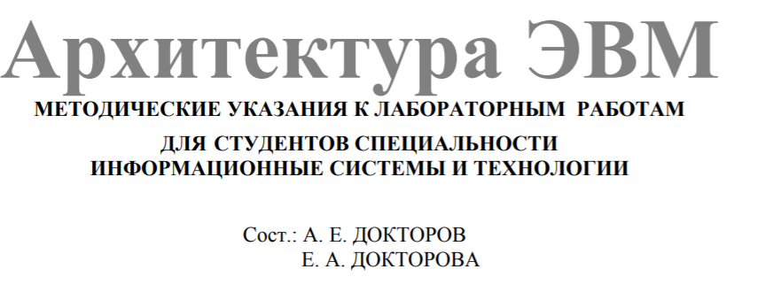

Эта книга содержит таблицы команд Ассемблера, по которым вполне можно строить дальнейшие планы по изучению языка. Только не все из этих команд ныне работают...

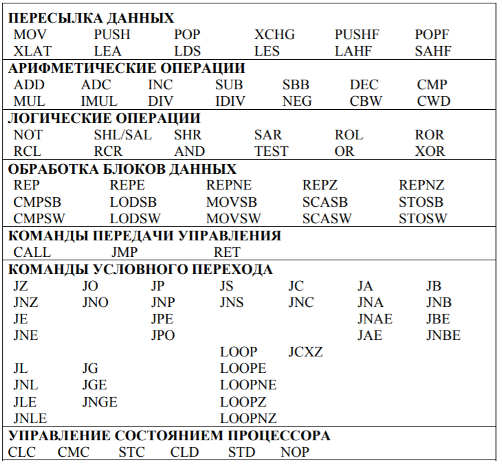

# Команды пересылки данных

Итак, приступим. Первая серьёзная лабораторная работа. Если материал изучается на том или ином этапе, знайте, что позже вернуться к нему возможности не будет.  
Почему? Потому что изучение глубин Ассемблера перспективами уходит в бесконечность. Материала много, самостоятельно его почти не изучить, малейшая безалаберность на уроке приводит к почти полному выпаданию из последующих тем курса. Дабы это предотвратить выполняется по 2 задания на человека. Разрешено командное выполнение, при условии - по 2 задачи на каждого члена команды.  
Почему так? Если этого не сделать, то можно можно почти сразу получить стадию бесконечного повторения предыдущего материала.  
Если на данной лабораторной работе в группе это не предотвратить, то до конца курса добросовестно доходят единицы.

Выполняется на Visual Studio/с++

# Лабораторная работа

Варианты заданий.

- 1) Обменять значения в переменных int x; и int *yy;, где int* yy - указатель.
- 2) Обменять значения в переменных $x[4]$ и $yy[3]$;, где yy - указатель на элемент массива.
- 3) Обменять значения в переменных $x[4]$ и $yy[3]$;, где yy - указатель на элемент массива. Используйте команды PUSH и POP для временного хранения элементов массива в стеке.
- 4) Сделать то же самое с использованием команды LEA.
- 5) Используя команды пересылок, покажите, как работает команда CMC.
- 6) Содержимое регистра флагов поместить в переменную int x;.
- 7) Обменять значения в переменных int x; и int *yy;, где int* yy - указатель. При этом использовать команду XCHG.

Перед лабораторной работой рекомендуется дать задание студентам на самостоятельный поиск информации по командам пересылки данных в Интернете или других источниках.

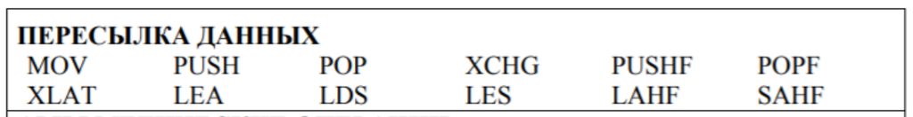

# А теперь теория

Предком современного Ассемблера является Intel 8086. Поэтому регистры общего назначения называются A, B, C, D. При этом они хранят машинные слова Byte (8 бит), Word (16 бит), DWord (32 бит).  
Вот более полная таблица, взятая из "Tomasz Grysztar. Flat assemdler 1.73 Programmer's Manual." [Официальный сайт.](https://flatassembler.net/)

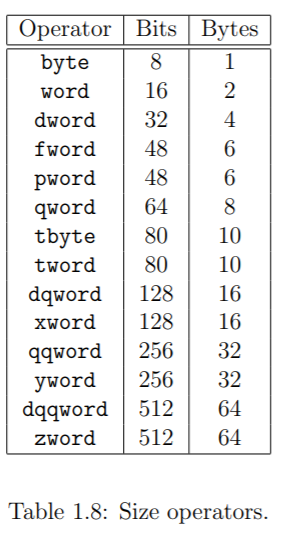

- RAX - 64 битный регистр
- EAX - 32 битный регистр. Нижняя половина регистра RAX.
- AX - 16 битный регистр. Нижняя половина регистра EAX.
- AL - 8 битный регистр. Нижняя половина регистра AX.
- AH - 8 битный регистр. Верхняя половина регистра AX.

С остальными регистрами общего назначения - по аналогии.  
Ожидается, что учащийся обладает навыками С++.